# PRÁCTICA OPTIMIZACIÓN

## EJERCICIO 1.

En este ejercicio trabajaremos con datos de criptomonedas, en concreto con los datos de las criptomonedas que tenemos en el fondo de inversión *Burro Navideño*. Por lo tanto trabajaremos con un problema real, que es en el que se encuentra el fondo de inversión que dirigimos Alejandro Gómez Ródenas y yo, Alejandro Vaca Serrano. El problema en concreto es que no dejan de registrarse pérdidas en el mercado, por lo que el valor de la cartera en cuestión no deja de bajar. Aunque tenemos buenas perspectivas en el medio-largo plazo respecto al mercado de las criptomonedas, es dudoso que en el corto plazo el mercado vaya a remontar, y más aún qué criptomonedas van o no van a sobrevivir. Por este motivo queremos plantear el siguiente problema de optimización.

Tenemos $x_{i}$ weights (proporción en cartera) de i criptomonedas. Éstas tienen $\mu_{i}$ retornos pasados, es decir el retorno medio diario del último año. De esta forma podemos plantear el problema de optimización como maximizar el retorno medio esperado de la cartera en el próximo año, asumiendo que el retorno medio diario de los activos que tenemos ahora mismo en cartera se mantendrá en el futuro, lo cual bien sabemos es demasiado suponer.

Además, le añadiremos algunas restricciones basadas en [este trabajo](https://github.com/alexvaca0/TFG18), [publicado entero en mi página de github](https://alexvaca0.github.io/2018/04/21/Complete-Graduate-Thesis,-Introduction-to-a-Tradin.html) con código incluido (aunque lamentablemente no se ven las imágenes, ya que al transformarlo de Word a HTML esto se perdió), que realicé el año pasado. Para ello se realizaron análisis de cluster, entre otros, para descubrir los diferentes tipos de criptomonedas que hay en función de sus protocolos, funcionalidades, ventajas, etc respecto a las demás. Pudimos detectar diferentes tipos de criptomonedas, como se puede ver en el trabajo. A cada uno de esos tipos de criptomonedas les asignamos unos pesos en base a unos parámetros que se pueden consultar en el trabajo. Estos pesos (actualizados) son:

Restricciones de los weights

1. Main Cryptocurrencies (Bitcoin, Ether): 50%

2. Platform Cryptocurrencies (Ripple, NEO, XEM): 20%

3. Protocol Cryptocurrencies (EOS, LSK, IOTA): 10%

4. Anonimity Cryptocurrencies (DASH, ZEC, XMR): 20%

El único cambio que he realizado ha sido quitar el 5% en speculative tokens e introducírselo a protocol cryptocurrencies.

El objetivo, por tanto, será seleccionar los weights óptimos, similar a como haríamos con una cartera de valores. Sin embargo, en este caso no queremos calcular una frontera eficiente, ni vamos a tener en cuenta la volatilidad de momento. Esto se debe a que el inversor en criptomonedas es tipicamente 0% risk-averse y por lo tanto ese lado de la ecuación sería siempre 0, no se tendría nada en cuenta la volatilidad. No queremos minimizar la volatilidad ni encontrar optimal resource allocations basados en el risk-aversion rate de un agente; lo que queremos es, asumiendo que los precios de las criptomonedas se pueden seguir comportando parecido en el próximo año, decidir las nuevas cantidades de criptomonedas que debemos escoger para la cartera solo atendiendo al $\mu_{i}$ de cada criptomoneda y a las restricciones. En este caso lo que nos aportará diversificación serán estas restricciones, ya que mediante éstas nos aseguramos que estamos asignando los pesos en cartera de tal forma que diferentes aplicaciones exitosas de la tecnología Blockchain nos puedan aportar beneficios.

En primer lugar descargaremos los datos a través de la API de [cryptocompare](https://www.cryptocompare.com/). El resto de pasos se irán especificando a lo largo del Notebook.

```python
import requests
import datetime
import pandas as pd
import numpy as np
import matplotlib.pyplot as plt
%matplotlib inline
plt.style.use('fivethirtyeight')
```

```python
#plt.rcParams.keys()
```

```python
plt.rcParams['figure.figsize'] = (12, 12)
```

```python
# Pretty print the JSON
import uuid
from IPython.display import display_javascript, display_html, display
import json

class RenderJSON(object):
    def __init__(self, json_data):
        if isinstance(json_data, dict):
            self.json_str = json.dumps(json_data)
        else:
            self.json_str = json_data
        self.uuid = str(uuid.uuid4())

    def _ipython_display_(self):
        display_html('<div id="{}" style="height: 600px; width:100%;"></div>'.format(self.uuid), raw=True)
        display_javascript("""
        require(["https://rawgit.com/caldwell/renderjson/master/renderjson.js"], function() {
        document.getElementById('%s').appendChild(renderjson(%s))
        });
        """ % (self.uuid, self.json_str), raw=True)
```

```python
def daily_price_historical(symbol, comparison_symbol, limit=1, aggregate=1, exchange='', allData='true'):
    url = 'https://min-api.cryptocompare.com/data/histoday?fsym={}&tsym={}&limit={}&aggregate={}&allData={}'\
            .format(symbol.upper(), comparison_symbol.upper(), limit, aggregate, allData)
    if exchange:
        url += '&e={}'.format(exchange)
    page = requests.get(url)
    data = page.json()['Data']
    df = pd.DataFrame(data)
    df['timestamp'] = [datetime.datetime.fromtimestamp(d) for d in df.time]
    return df
```

```python
symbols = ['BTC', 'ETH', 'XRP', 'NEO', 'XEM', 'EOS', 'LSK', 'DASH', 'ZEC', 'XMR']

list_of_dfs = [daily_price_historical(symbol = symbol, comparison_symbol = 'USD', limit = 365) for symbol in symbols]
```

Una vez tenemos todas las criptomonedas que tenemos actualmente en cartera guardadas cada una en un DataFrame y todos estos df guardados en una lista, vamos a hacer un poco de limpieza. Como estamos interesados únicamente en los datos del último año, vamos a cortar estos df de tal forma que tan sólo incluyan las últimas 365 observaciones.

**Nota: Como cuando yo descargué estos datos por primera vez y resolví el problema de optimización será una fecha anterior a la última ejecución del Notebook previa a la entrega, es posible que exista alguna pequeña variación en el vector de retornos medios diarios $\mu$.**

```python
#list_of_dfs[0].iloc[-365:]

def cut_dfs(df_list = list_of_dfs, period = 365):

    '''
    Takes a list of dataframes and cuts it for the selected period; the default is 1 year
    --inputs:
        - df_list: list with dfs
        - period: number of days before today to substract
    --returns:
        - new_list: new list with dfs cut.
     '''
    new_list = []

    for df in list_of_dfs:

        new_list.append(df.iloc[-period:])

    return new_list

newlist = cut_dfs()
```

```python
def add_rets_and_volatility(df_list = newlist):

    for df in df_list:

        df.loc[:,'ret'] = df.loc[:, 'close'].pct_change()

        df.loc[:,'logret'] = np.log(df.loc[:, 'close']) - np.log(df.loc[:, 'close'].shift(1))

        df.loc[:,'volatility'] = (df.loc[:, 'high'] - df.loc[:, 'low']) / df.loc[:, 'open']

    return df_list

newlist = add_rets_and_volatility()
```

[output not shown]

El error que nos sale arriba está comprobado y hemos realizado la indexación siguiendo la documentación, por lo que pese a ser un warning no supone ningún problema. Los valores obtenidos en los dataframe con las nuevas columnas son los correctos y no se ha producido ningún cambio inesperado en estos df. A modo más bien ilustrativo, vamos a obtener una matriz objetiva que nos de determinados datos de las criptomonedas, más que nada a modo de resumen de la cartera. Las características que nos interesan se pueden ver en el código inferior:

```python
def get_objective_matrix(df_list=newlist, capital_inicial = 2000):

    dic = {'cryptos': ['BTC', 'ETH', 'XRP', 'NEO', 'XEM', 'EOS', 'LSK', 'DASH', 'ZEC', 'XMR'],
          'type': ['main', 'main', 'platform', 'platform', 'platform', 'protocol', 'protocol', 'anonimity', 'anonimity', 'anonimity'],
          'av_ret': [],
          'av_vol': [],
          'tot_ret': [],
          'current_weights': [0.256, 0.244, 0.058, 0.083, 0.059,0.06699999999999995, 0.034, 0.07, 0.064, 0.065],
          'amount_initial': [],
           'value_initial': [],
          'valor_actual': []}

    for df, weight in zip(df_list, dic['current_weights']):

        dic['av_ret'].append(np.mean(df['logret'].iloc[1:]))

        dic['av_vol'].append(np.mean(df['volatility']))

        dic['tot_ret'].append((df['close'].iloc[len(df)-1] - df['open'].iloc[0]) / df['open'].iloc[0])

        dic['amount_initial'].append(capital_inicial*weight/df['open'].iloc[0])

        dic['value_initial'].append(capital_inicial*weight)

        dic['valor_actual'].append(dic['amount_initial'][-1]*df['close'].iloc[len(df)-1])


    return pd.DataFrame(dic)

objective_matrix = get_objective_matrix()

pd.DataFrame(objective_matrix)
```

|  | cryptos | type | av_ret | av_vol | tot_ret | current_weights | amount_initial | value_initial | valor_actual |
| --- | --- | --- | --- | --- | --- | --- | --- | --- | --- |
| 0 | BTC | main | -0.003541 | 0.060649 | -0.754189 | 0.256 | 0.034316 | 512.0 | 125.855280 |
| 1 | ETH | main | -0.005995 | 0.082884 | -0.897090 | 0.244 | 0.390725 | 488.0 | 50.219895 |
| 2 | XRP | platform | -0.004837 | 0.095115 | -0.829846 | 0.058 | 59.487179 | 116.0 | 19.737846 |
| 3 | NEO | platform | -0.007142 | 0.108520 | -0.935031 | 0.083 | 1.354881 | 166.0 | 10.784851 |
| 4 | XEM | platform | -0.008504 | 0.106112 | -0.958708 | 0.059 | 86.131387 | 118.0 | 4.872453 |
| 5 | EOS | protocol | -0.004170 | 0.111161 | -0.779464 | 0.067 | 11.964286 | 134.0 | 29.551786 |
| 6 | LSK | protocol | -0.008430 | 0.120725 | -0.960748 | 0.034 | 2.118380 | 68.0 | 2.669159 |
| 7 | DASH | anonimity | -0.007172 | 0.090216 | -0.933062 | 0.070 | 0.127466 | 140.0 | 9.371318 |
| 8 | ZEC | anonimity | -0.006758 | 0.093646 | -0.923084 | 0.064 | 0.178549 | 128.0 | 9.845192 |
| 9 | XMR | anonimity | -0.005640 | 0.092766 | -0.887738 | 0.065 | 0.322165 | 130.0 | 14.594072 |

Sólo hace falta ver el DataFrame de arriba para ver el verdadero desastre que ha sido este año para la cotización de las criptomonedas. Tratando de aguantarnos las ganas de llorar, nos encomendamos a la Programación Lineal y a Pyomo para ver si nos pueden ayudar a minimizar el golpe de esta situación.

```python
h={}

lista = ['a', 'b']
lista2 = [1, 2]
for i in range(len(lista)):
    h[lista[i]] = lista2[i]

h
```

```
{'a': 1, 'b': 2}
```

```python
def get_ret_df(df_list = newlist, n = 10, names = ['BTC', 'ETH', 'XRP', 'NEO', 'XEM', 'EOS', 'LSK', 'DASH', 'ZEC', 'XMR']):

    new = np.zeros((df_list[0].shape[0] -1, n))

    for i in range(n):

        new[:, i] = df_list[i]['logret'].iloc[1:]

    cov_mat = pd.DataFrame(new).cov()

    return new, cov_mat, pd.DataFrame(new, columns = names)
```

```python
ret_arr, cov_matrix, ret_df = get_ret_df()
```

```python
ret_df.shape
```

```
(364, 10)
```

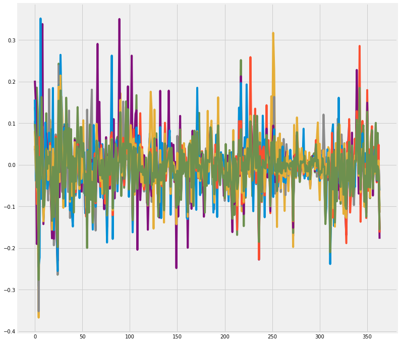

```python
for col in range(ret_arr.shape[1]):

    plt.plot(range(len(ret_arr[:,col])), ret_arr[:,col])
```

En el gráfico de arriba se pueden ver los retornos de las criptomonedas a lo largo del año; lo único que queríamos era ver cómo algunas han llegado a tener días verdaderamente malos, de caer más de un 30%, mientras que otras se han mantenido algo más estables. Como el objetivo de este proyecto no es graficar bonito, no viene leyenda incluida ni similares. Tampoco nos interesa saber cuáles son cada una de esas criptomonedas del gráfico (además de que se ve bastante poco).

```python
#objective_matrix

perdidas = np.sum(objective_matrix['valor_actual']) - 2000
perdidas
```

```
-1722.4981477944102
```

Como vemos, se registran unas pérdidas abismales, de 1722 dólares. Por este motivo queremos reajustar el peso de los activos en cartera de tal forma que hayemos una composición más eficiente de la misma, y así podamos tratar de recuperar al menos parte del capital perdido. El objetivo ahora será seleccionar de esta objective matrix los elementos que sean de interés (retorno medio diario, retorno total en el año, pesos...) de tal forma que podamos formular correctamente el problema de optimización que se plantea.

```python
mean_daily_returns = pd.DataFrame(ret_arr[1:, :]).mean()
mean_daily_returns
```

```
0   -0.003659
1   -0.006291
2   -0.004976
3   -0.007545
4   -0.008820
5   -0.004740
6   -0.008886
7   -0.007324
8   -0.007001
9   -0.005926
dtype: float64
```

La variable mean_daily_returns es nuestro vector $\mu$, el cual le introduciremos a Pyomo próximamente.

Pese a que no estamos interesados en el problema clásico del [Optimal Portfolio de Markowitz](https://www.math.ust.hk/~maykwok/courses/ma362/07F/markowitz_JF.pdf), vamos a dibujar (sobre todo por ver cómo quedaría y porque se haga el lector una idea del absurdo de intentar obtener una frontera eficiente en un mercado en el que los activos están tan correlacionados y en el que la volatilidad es tan alta) un par de gráficos:

1. Gráfico de la matriz de correlaciones de nuestra cartera.
2. Gráfico de 25000 asignaciones diferentes de pesos en el portfolio (en estos gráficos, cuando se hace con una cartera de valores que tenga cierto sentido y criterio, se puede observar una "frontera eficiente" donde los Sharpe Ratios son óptimos en función de la aversión al riesgo de cada cliente). Esto se suele utilizar para, en función de donde esté el principal interés del cliente (si en maximizar retorno o minimizar la volatilidad), elegir una composición en cartera u otra.

```python
np.sum(np.isnan(ret_df))
```

```
BTC     0
ETH     0
XRP     0
NEO     0
XEM     0
EOS     0
LSK     0
DASH    0
ZEC     0
XMR     0
dtype: int64
```

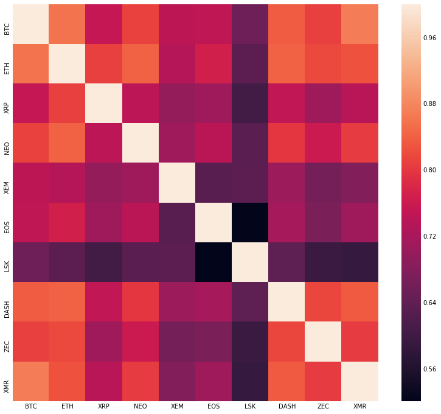

```python
import seaborn as sns

sns.heatmap(ret_df.corr())
```

Como vemos, no solamente son correlaciones fuertes, sino que son todas positivas. Como vemos, estas son las dificultades de participar en este mercado, y el motivo por el que transformamos el problema de optimización de la forma que veremos más adelante.

```python
#set number of runs of random portfolio weights
num_portfolios = 25000

#set up array to hold results
results = np.zeros((3,num_portfolios))

for i in range(num_portfolios):
    #select random weights for portfolio holdings
    weights = np.random.random(10)
    #rebalance weights to sum to 1
    weights /= np.sum(weights)

    #calculate portfolio return and volatility
    portfolio_return = np.sum(mean_daily_returns * weights) * 365
    portfolio_std_dev = np.sqrt(np.dot(weights.T,np.dot(cov_matrix, weights))) * np.sqrt(365)

    #store results in results array
    results[0,i] = portfolio_return
    results[1,i] = portfolio_std_dev
    #store Sharpe Ratio (return / volatility) - risk free rate element excluded for simplicity
    results[2,i] = results[0,i] / results[1,i]
 #convert results array to Pandas DataFrame


results_frame = pd.DataFrame(results.T,columns=['ret','stdev','sharpe'])
```

```python
#locate position of portfolio with highest Sharpe Ratio
max_sharpe_port = results_frame.iloc[results_frame['sharpe'].idxmax()]
#locate positon of portfolio with minimum standard deviation
min_vol_port = results_frame.iloc[results_frame['stdev'].idxmin()]
```

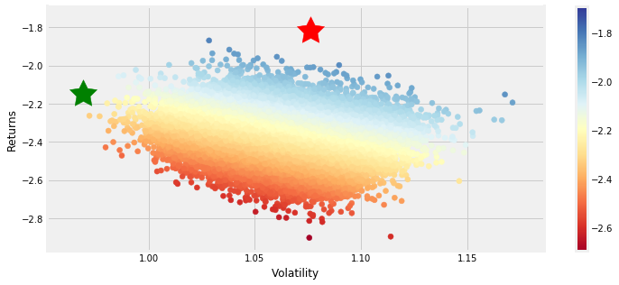

```python
plt.rcParams["figure.figsize"] = (11, 5)
#create scatter plot coloured by Sharpe Ratio
plt.scatter(results_frame.stdev,results_frame.ret,c=results_frame.sharpe,cmap='RdYlBu')
plt.xlabel('Volatility')
plt.ylabel('Returns')
plt.colorbar()
#plot red star to highlight position of portfolio with highest Sharpe Ratio
plt.scatter(max_sharpe_port[1],max_sharpe_port[0],marker=(5,1,0),color='r',s=1000)
#plot green star to highlight position of minimum variance portfolio
plt.scatter(min_vol_port[1],min_vol_port[0],marker=(5,1,0),color='g',s=1000)
```

En el gráfico que vemos arriba se pueden apreciar los diferentes "mix" de return-risk (medido como volatilidad del portfolio) para los diferentes 25000 pesos aleatorios que les hemos asignado a las criptomonedas. El color viene definido por el $Sharpe Ratio = \frac{Portfolio Return}{Portfolio Volatility}$. Hemos puesto una estrella roja en el punto con mayor sharpe ratio, y una estrella verde en el punto (mezcla de weights para esa simulación) de menor volatilidad.

Además de la variable objetivo $x_{i}$, el vector de retornos medios diarios $\mu$, y las restricciones ya mencionadas para los grupos de criptomonedas (la cual modificaremos ligeramente como se podrá ver en la próxima sección), tendremos una restricción adicional, por hacer el problema de optimización un poco más divertido, y es que forzaremos al modelo a incluir al menos un 1% de cada criptomoneda en el portfolio, no importa cuán mala haya sido su cotización de media el último año. De forma natural existe la restricción adicional de que ninguno de los pesos son 0, pues no podemos operar en corto en Binance.

## 1.A. Formulación del Problema de Programación Lineal

Recordamos las restricciones de los weights

1. Main Cryptocurrencies (Bitcoin, Ether): 50%

2. Platform Cryptocurrencies (Ripple, NEO, XEM): 20%

3. Protocol Cryptocurrencies (EOS, LSK): 10%

4. Anonimity Cryptocurrencies (DASH, ZEC, XMR): 20%

Donde:

1. $\mu^{T}$ : vector de logreturns medios diarios del último año

2. $x$ : vector de los weights de cada criptomoneda en cartera. Es la variable a optimizar.

3. $\gamma$ es un parámetro que indica la aversión al riesgo del inversor, es decir cuánto quiere evitar la volatilidad. Cuanto más alto es este parámetro, mayor aversión al riesgo. En un contexto como el de las criptomonedas podemos asumir que el inversor es 0 risk averse, ya que el mercado en sí mismo contiene un alto grado de riesgo, como se puede ver en el anterior gráfico en el que se aprecia que la volatilidad en cartera es siempre alta se escojan los weights que se escojan.

4. $\Sigma$ es la matriz de varianzas y covarianzas de los vectores de logreturns medios diarios del último año de todas las criptomonedas en consideración

Vemos, por tanto, que la primera parte de la ecuación trata de maximizar el return, mientras que la segunda parte trata de minimizar la varianza total del portfolio. Como se comentó previamente, el inversor en criptomonedas, y nuestro pequeño fondo de inversión en concreto, es 0 risk averse, de hecho lo interesante desde el punto de vista de la construcción de modelos de alta frecuencia para predecir los movimientos de precios es que exista una cierta volatilidad, pues en los cambios en los precios, especialmente si se obtienen variables explicativas a cuyos nuevos valores responden esos cambios en los precios, está la información sobre los patrones que siguen.

En primer lugar, la suma de los pesos ha de ser 1. No se valora una reducción del volumen de cartera, solo un cambio en los pesos de la misma. Para cada criptomoneda, se determina que el peso de esta no podrá superar el peso máximo asignado para el grupo al que pertenece. Además, se añade la restricción de que cada criptomoneda debe tener al menos un peso del 1%.

## 1. B. Implementación en Pyomo

```python
%%writefile problema1.py

from pyomo.environ import *

model = AbstractModel()

model.n = Param(within = NonNegativeIntegers)#n va a ser el número de criptomonedas

model.I = RangeSet(1, model.n) #esto será para los índices

model.mu = Param(model.I) #retorno medio diario


model.b = Param(model.I) #proporción máxima de cada grupo de criptos.

model.x = Var(model.I, domain = NonNegativeReals)



#FO: Función Objetivo


def obj_funct(model):

    return sum(-model.mu[i]*model.x[i] for i in model.I)


model.OBJ = Objective(rule = obj_funct)

#constraint de cumplir que la suma de los pesos sea = 1.
def max_weights(model):

    return sum(model.x[i] for i in model.I)  == 1


model.max_weights = Constraint(rule = max_weights)


#maximos pesos de cada grupo de criptomonedas.

def minim(model, i):
    return model.x[i] >=  0.01

model.minimum_position = Constraint(model.I, rule = minim)

def maximum_weights(model, i):

    return model.x[i] <= model.b[i]

model.maximum_weights = Constraint(model.I, rule = maximum_weights)
```

```
Overwriting problema1.py
```

```python
%%writefile problema1.dat

param n := 10;



param b :=
1 0.5
2 0.5
3 0.1
4 0.1
5 0.1
6 0.2
7 0.2
8 0.2
9 0.2
10 0.2
;

param mu:=
1 -0.003760
2 -0.005193
3 -0.005512
4 -0.007055
5 -0.008981
6 -0.003416
7 -0.007500
8 -0.007183
9 -0.006133
10 -0.005658
;
```

```
Overwriting problema1.dat
```

```python
!pyomo solve problema1.py problema1.dat --solver=glpk --summary --solver-suffix=dual
```

```
[    0.00] Setting up Pyomo environment
[    0.00] Applying Pyomo preprocessing actions
[    0.01] Creating model
[    0.03] Applying solver
[    0.09] Processing results
    Number of solutions: 1
    Solution Information
      Gap: 0.0
      Status: feasible
      Function Value: 0.004237810000000001
    Solver results file: results.yml

==========================================================
Solution Summary
==========================================================

Model unknown

  Variables:
    x : Size=10, Index=I
        Key : Lower : Value : Upper : Fixed : Stale : Domain
          1 :     0 :   0.5 :  None : False : False : NonNegativeReals
          2 :     0 :  0.23 :  None : False : False : NonNegativeReals
          3 :     0 :  0.01 :  None : False : False : NonNegativeReals
          4 :     0 :  0.01 :  None : False : False : NonNegativeReals
          5 :     0 :  0.01 :  None : False : False : NonNegativeReals
          6 :     0 :   0.2 :  None : False : False : NonNegativeReals
          7 :     0 :  0.01 :  None : False : False : NonNegativeReals
          8 :     0 :  0.01 :  None : False : False : NonNegativeReals
          9 :     0 :  0.01 :  None : False : False : NonNegativeReals
         10 :     0 :  0.01 :  None : False : False : NonNegativeReals

  Objectives:
    OBJ : Size=1, Index=None, Active=True
        Key  : Active : Value
        None :   True : 0.004237810000000001

  Constraints:
    max_weights : Size=1
        Key  : Lower : Body : Upper
```

[output cut: 13 more lines]

```
    maximum_weights : Size=10
        Key : Lower : Body : Upper
          1 :  None :  0.5 :   0.5
          2 :  None : 0.23 :   0.5
          3 :  None : 0.01 :   0.1
          4 :  None : 0.01 :   0.1
          5 :  None : 0.01 :   0.1
          6 :  None :  0.2 :   0.2
          7 :  None : 0.01 :   0.2
          8 :  None : 0.01 :   0.2
          9 :  None : 0.01 :   0.2
         10 :  None : 0.01 :   0.2

[    0.10] Applying Pyomo postprocessing actions
[    0.10] Pyomo Finished
```

```python
!type results.yml
```

```
# ==========================================================
# = Solver Results                                         =
# ==========================================================
# ----------------------------------------------------------
#   Problem Information
# ----------------------------------------------------------
Problem:
- Name: unknown
  Lower bound: 0.00423781
  Upper bound: 0.00423781
  Number of objectives: 1
  Number of constraints: 22
  Number of variables: 11
  Number of nonzeros: 31
  Sense: minimize
# ----------------------------------------------------------
#   Solver Information
# ----------------------------------------------------------
Solver:
- Status: ok
  Termination condition: optimal
  Statistics:
    Branch and bound:
      Number of bounded subproblems: 0
      Number of created subproblems: 0
  Error rc: 0
  Time: 0.027431249618530273
# ----------------------------------------------------------
#   Solution Information
# ----------------------------------------------------------
Solution:
- number of solutions: 1
  number of solutions displayed: 1
- Gap: 0.0
  Status: feasible
  Message: None
  Objective:
    OBJ:
      Value: 0.004237810000000001
  Variable:
```

[output cut: 26 more lines]

```
      Dual: -0.001777
    minimum_position[10]:
      Dual: 0.000465
    minimum_position[3]:
      Dual: 0.000319000000000001
    minimum_position[4]:
      Dual: 0.001862
    minimum_position[5]:
      Dual: 0.003788
    minimum_position[7]:
      Dual: 0.002307
    minimum_position[8]:
      Dual: 0.00199
    minimum_position[9]:
      Dual: 0.000940000000000001
```

```python
value_primal = 0.00423781
```

## 1.C. Resolución del Problema Dual Asociado al Problema Primal Resuelto en A)

A partir del problema primal, que podemos reescribir de la siguiente forma (después de los 2 puntos en cada restricción vemos las variables duales asociadas):

\begin{align*} \text{minimize}_x\quad & - \mu^T x \\ \text{subject to}&\\ & \sum x_i = 1 : \lambda \\ & - x_{i} \geq - b_{i} : \gamma \\ & x_{i} \geq 0.01 : \beta \end{align*}

podemos plantear el siguiente problema dual:

\begin{align*} \text{maximize}_{\lambda, \beta, \gamma}\quad & \lambda + 0.01 \cdot \sum_{i}^{n} \beta_{i} - \sum_{i}^{n} b_{i} \cdot \gamma_{i} \\ \text{subject to}&\\ & \lambda + \beta_{i} - \gamma_{i} = - \mu_{i} \\ & \beta_{i}, \gamma_{i} \geq 0 \end{align*}

```python
%%writefile problema_dual.py

from pyomo.environ import *

model = AbstractModel()

model.n = Param(within = NonNegativeIntegers)#n va a ser el número de restricciones ahora.

model.m = Param(within = NonNegativeIntegers)

model.I = RangeSet(1, model.n) #esto será para los índices

model.J = RangeSet(1, model.m) #esto será para las criptomonedas que hay.

model.mu = Param(model.J) #retorno medio diario

model.lamb = Var(within = Reals)

model.beta = Var(model.J, domain = NonNegativeReals)

model.gamma = Var(model.J, domain = NonNegativeReals)

model.b = Param(model.J)


def obj_funct(model):

    return model.lamb + 0.01*sum(model.beta[j] for j in model.J) - summation(model.b, model.gamma)

model.OBJ = Objective(rule = obj_funct, sense = maximize)


def dual_constraint(model, j):

    return model.lamb + model.beta[j] - model.gamma[j] == -model.mu[j]

model.dual_cons = Constraint(model.J, rule = dual_constraint)
```

```
Overwriting problema_dual.py
```

```python
%%writefile problema_dual.dat

param n := 21;

param m := 10;




param b :=
1 0.5
2 0.5
3 0.1
4 0.1
5 0.1
6 0.2
7 0.2
8 0.2
9 0.2
10 0.2
;

param mu :=
1 -0.003760
2 -0.005193
3 -0.005512
4 -0.007055
5 -0.008981
6 -0.003416
7 -0.007500
8 -0.007183
9 -0.006133
10 -0.005658
;
```

```
Overwriting problema_dual.dat
```

```python
!pyomo solve problema_dual.py problema_dual.dat --solver=glpk --summary
```

```
[    0.00] Setting up Pyomo environment
[    0.00] Applying Pyomo preprocessing actions
[    0.03] Creating model
[    0.05] Applying solver
[    0.10] Processing results
    Number of solutions: 1
    Solution Information
      Gap: 0.0
      Status: feasible
      Function Value: 0.00423781
    Solver results file: results.yml

==========================================================
Solution Summary
==========================================================

Model unknown

  Variables:
    lamb : Size=1, Index=None
        Key  : Lower : Value    : Upper : Fixed : Stale : Domain
        None :  None : 0.005193 :  None : False : False :  Reals
    beta : Size=10, Index=J
        Key : Lower : Value                : Upper : Fixed : Stale : Domain
          1 :     0 :                  0.0 :  None : False : False : NonNegativeReals
          2 :     0 :                  0.0 :  None : False : False : NonNegativeReals
          3 :     0 : 0.000319000000000001 :  None : False : False : NonNegativeReals
          4 :     0 :             0.001862 :  None : False : False : NonNegativeReals
          5 :     0 :             0.003788 :  None : False : False : NonNegativeReals
          6 :     0 :                  0.0 :  None : False : False : NonNegativeReals
          7 :     0 :             0.002307 :  None : False : False : NonNegativeReals
          8 :     0 :              0.00199 :  None : False : False : NonNegativeReals
          9 :     0 : 0.000940000000000001 :  None : False : False : NonNegativeReals
         10 :     0 :             0.000465 :  None : False : False : NonNegativeReals
    gamma : Size=10, Index=J
        Key : Lower : Value    : Upper : Fixed : Stale : Domain
          1 :     0 : 0.001433 :  None : False : False : NonNegativeReals
          2 :     0 :      0.0 :  None : False : False : NonNegativeReals
          3 :     0 :      0.0 :  None : False : False : NonNegativeReals
          4 :     0 :      0.0 :  None : False : False : NonNegativeReals
```

[output cut: 13 more lines]

```
    dual_cons : Size=10
        Key : Lower    : Body                  : Upper
          1 :  0.00376 : 0.0037599999999999995 :  0.00376
          2 : 0.005193 :              0.005193 : 0.005193
          3 : 0.005512 :              0.005512 : 0.005512
          4 : 0.007055 :              0.007055 : 0.007055
          5 : 0.008981 :              0.008981 : 0.008981
          6 : 0.003416 : 0.0034159999999999998 : 0.003416
          7 :   0.0075 :                0.0075 :   0.0075
          8 : 0.007183 :              0.007183 : 0.007183
          9 : 0.006133 :              0.006133 : 0.006133
         10 : 0.005658 :              0.005658 : 0.005658

[    0.12] Applying Pyomo postprocessing actions
[    0.12] Pyomo Finished
```

```python
!type results.yml
```

```
# ==========================================================
# = Solver Results                                         =
# ==========================================================
# ----------------------------------------------------------
#   Problem Information
# ----------------------------------------------------------
Problem:
- Name: unknown
  Lower bound: 0.00423781
  Upper bound: 0.00423781
  Number of objectives: 1
  Number of constraints: 11
  Number of variables: 22
  Number of nonzeros: 31
  Sense: maximize
# ----------------------------------------------------------
#   Solver Information
# ----------------------------------------------------------
Solver:
- Status: ok
  Termination condition: optimal
  Statistics:
    Branch and bound:
      Number of bounded subproblems: 0
      Number of created subproblems: 0
  Error rc: 0
  Time: 0.03138279914855957
# ----------------------------------------------------------
#   Solution Information
# ----------------------------------------------------------
Solution:
- number of solutions: 1
  number of solutions displayed: 1
- Gap: 0.0
  Status: feasible
  Message: None
  Objective:
    OBJ:
      Value: 0.00423781
  Variable:
    beta[10]:
      Value: 0.000465
    beta[3]:
      Value: 0.000319000000000001
    beta[4]:
      Value: 0.001862
    beta[5]:
      Value: 0.003788
    beta[7]:
      Value: 0.002307
    beta[8]:
      Value: 0.00199
    beta[9]:
      Value: 0.000940000000000001
    gamma[1]:
      Value: 0.001433
    gamma[6]:
      Value: 0.001777
    lamb:
      Value: 0.005193
  Constraint: No values
```

```python
value_dual = 0.00423781

def strong_duality_theorem(primal, dual):

    if primal == dual:
        return print("SE CUMPLE EL TEOREMA DE DUALIDAD FUERTE")

strong_duality_theorem(value_primal, value_dual)
```

```
SE CUMPLE EL TEOREMA DE DUALIDAD FUERTE
```

Además del teorema de dualidad fuerte que vemos que se cumple, si comparamos el valor que toman las variables $\beta, \ \gamma \ y \ \lambda$, se cumple con las sensibilidades que se obtuvieron previamente.

## 1. D. Resolución del Problema Binario

Para introducirle alguna restricción lógica, lo que haremos será seguir forzando al modelo a que la suma de todos sus pesos sea 1, mientras que haremos que la variable x ahora sea binaria, mientras que el resto de restricciones las eliminamos (sino no nos quedaría ninguna región factible, ya que si los pesos tienen que ser 1 o 0, solo podremos quedarnos con 1 criptomoneda en cartera, por lo tanto si le impusiéramos las restricciones de pesos máximos o mínimos que vimos arriba no quedaría ninguna región factible).

El problema de optimización ahora es por tanto el siguiente:

Decision variables: $$ x_i = \left\{\begin{array}{ll} 1, & \text{if cryptocurrency $i$ is selected,}\\ 0, & \text{if cryptocurrency $i$ is not selected} \end{array} \right.\quad i=1,2,3,4,5, 6, 7, 8, 9, 10 $$

\begin{align*} \text{minimize}_x\quad & - \mu^T x \\ \text{subject to}&\\ &\sum x_i = 1 \\ \end{align*}

```python
%%writefile problema_binario.py

from pyomo.environ import *

model = AbstractModel()

model.n = Param(within = NonNegativeIntegers)#n va a ser el número de criptomonedas

model.I = RangeSet(1, model.n) #esto será para los índices

model.mu = Param(model.I) #retorno medio diario

model.x = Var(model.I, domain = Binary)


#FO: Función Objetivo


def obj_funct(model):

    return sum(-model.mu[i]*model.x[i] for i in model.I)


model.OBJ = Objective(rule = obj_funct)

#constraint de cumplir que la suma de los pesos sea = 1.
def max_weights(model):

    return sum(model.x[i] for i in model.I)  == 1

model.max_weights = Constraint(rule = max_weights)
```

```
Overwriting problema_binario.py
```

```python
%%writefile problema_binario.dat

param n := 10;


param mu:=
1 -0.003760
2 -0.005193
3 -0.005512
4 -0.007055
5 -0.008981
6 -0.003416
7 -0.007500
8 -0.007183
9 -0.006133
10 -0.005658
;
```

```
Overwriting problema_binario.dat
```

```python
!pyomo solve problema_binario.py problema_binario.dat --solver=glpk --summary --solver-suffix=dual
```

```
[    0.00] Setting up Pyomo environment
[    0.00] Applying Pyomo preprocessing actions
[    0.02] Creating model
[    0.04] Applying solver
[    0.11] Processing results
    Number of solutions: 1
    Solution Information
      Gap: 0.0
      Status: optimal
      Function Value: 0.003416
    Solver results file: results.yml

==========================================================
Solution Summary
==========================================================

Model unknown

  Variables:
    x : Size=10, Index=I
        Key : Lower : Value : Upper : Fixed : Stale : Domain
          1 :     0 :   0.0 :     1 : False : False : Binary
          2 :     0 :   0.0 :     1 : False : False : Binary
          3 :     0 :   0.0 :     1 : False : False : Binary
          4 :     0 :   0.0 :     1 : False : False : Binary
          5 :     0 :   0.0 :     1 : False : False : Binary
          6 :     0 :   1.0 :     1 : False : False : Binary
          7 :     0 :   0.0 :     1 : False : False : Binary
          8 :     0 :   0.0 :     1 : False : False : Binary
          9 :     0 :   0.0 :     1 : False : False : Binary
         10 :     0 :   0.0 :     1 : False : False : Binary

  Objectives:
    OBJ : Size=1, Index=None, Active=True
        Key  : Active : Value
        None :   True : 0.003416

  Constraints:
    max_weights : Size=1
        Key  : Lower : Body : Upper
        None :   1.0 :  1.0 :   1.0

[    0.12] Applying Pyomo postprocessing actions
[    0.12] Pyomo Finished
```

```python
!type results.yml
```

```
# ==========================================================
# = Solver Results                                         =
# ==========================================================
# ----------------------------------------------------------
#   Problem Information
# ----------------------------------------------------------
Problem:
- Name: unknown
  Lower bound: 0.003416
  Upper bound: 0.003416
  Number of objectives: 1
  Number of constraints: 2
  Number of variables: 11
  Number of nonzeros: 11
  Sense: minimize
# ----------------------------------------------------------
#   Solver Information
# ----------------------------------------------------------
Solver:
- Status: ok
  Termination condition: optimal
  Statistics:
    Branch and bound:
      Number of bounded subproblems: 1
      Number of created subproblems: 1
  Error rc: 0
  Time: 0.03923344612121582
# ----------------------------------------------------------
#   Solution Information
# ----------------------------------------------------------
Solution:
- number of solutions: 1
  number of solutions displayed: 1
- Gap: 0.0
  Status: optimal
  Message: None
  Objective:
    OBJ:
      Value: 0.003416
  Variable:
    x[6]:
      Value: 1
  Constraint: No values
```

Vemos que en este caso, si forzamos al modelo a quedarnos sólo con 1 criptomoneda, nos quedaríamos con la criptomoneda 6, es decir EOS.

```python
mean_daily_returns
```

```
0   -0.003584
1   -0.005486
2   -0.005166
3   -0.006700
4   -0.008682
5   -0.003356
6   -0.008761
7   -0.006991
8   -0.006643
9   -0.005525
dtype: float64
```

Como vemos arriba, tiene sentido este resultado ya que la criptomoneda que mayor retorno medio diario tuvo fue EOS, la criptomoneda elegida. Por lo tanto si nos tenemos que quedar con una, nos quedaremos con EOS.